# Analysing Covid Data From India

Vimal Simha

## Overview

I examine some basic aspects of the Covid Data from India. My data are sourced from https://www.covid19india.org.

## Exploratory Analysis

The figure shows the cumulative number of cases against date, starting from the day when there were 100 cases. It is the starting point of any analysis. It shows the number of cases rising roughly exponentially so far.

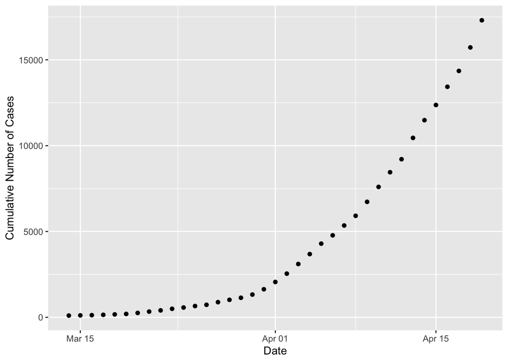

A key parameter of interest is the doubling period i.e. how many days does it take for the number of cases to double? There are a few equivalent ways of doing that. One is to fit an exponential curve to the figure above. To help visualise this better, the number of cases is plotted on a log axis which makes our exponential curve look like a straight line with its slope giving the reproduction rate (see appendix for details). The best-fit exponential curve is shown in the figure below and yields a doubling time of 4.1 days.

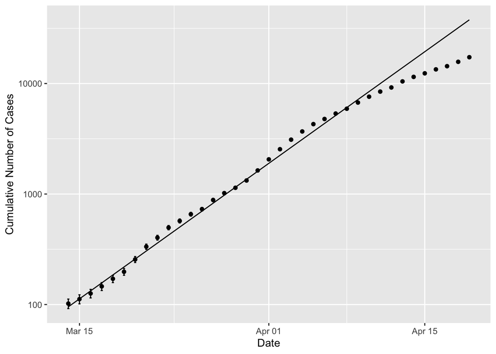

The figure below shows a plot of the number of new cases on a given day against the total number of cases on that day. It is roughly proportional, but with a lot of scatter.

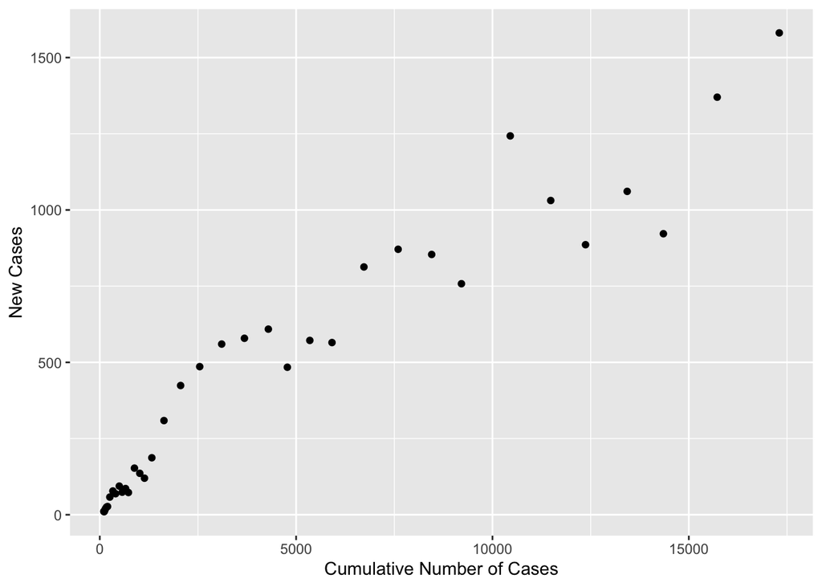

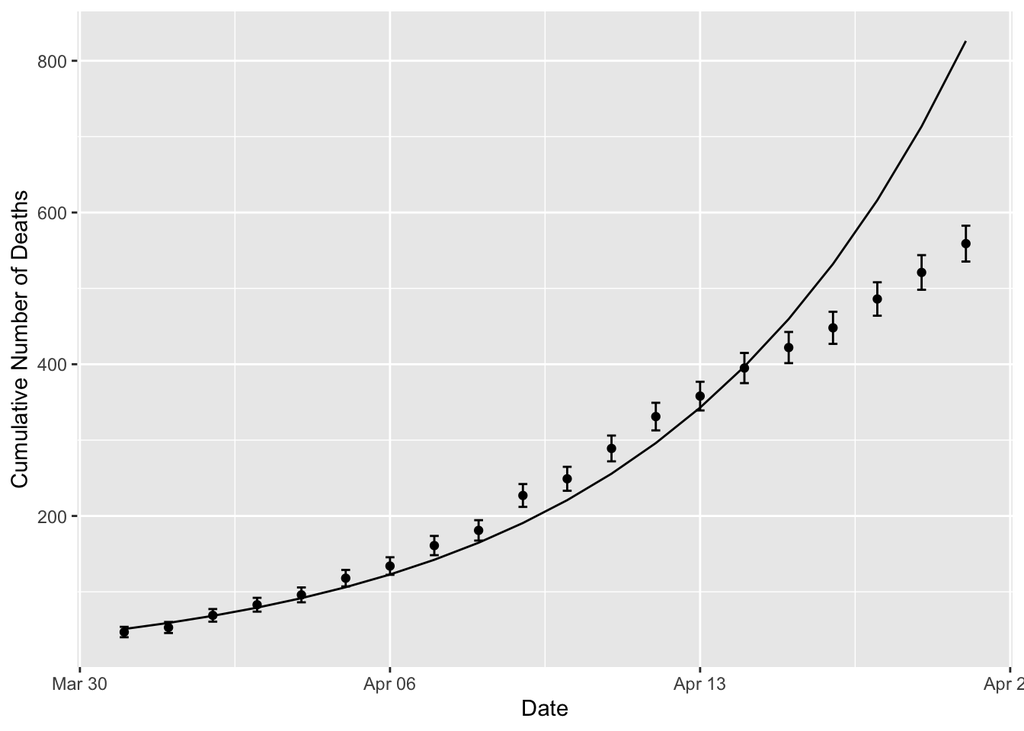

Another question of interest is whether the slope is changing i.e. is there evidence to suggest that the doubling rate is slowing down or speeding up? The figure below shows the daily growth rate over the last 3 day period i.e. we compute the number of new cases during the last 3 days and calculate the daily growth rate of the infected population that it implies.

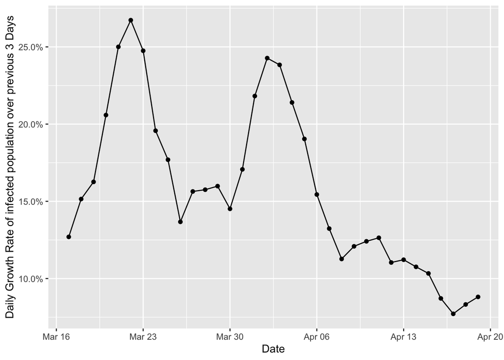

## Appendix: Computation of Doubling Rate from Reproduction Rate

Recall that, in the simplest models and during the initial stages in more complex models, the number of new cases $\Delta N$ is given by the reproduction rate, $r$ multiplied by the Number of cases, $N$,
$$\Delta N = r N$$
and therefore the number of cases after t time periods, $N$ is
$$N = N_0 (1+r)^t$$
where $N_0$ is the initial number of cases.

If we take the logarithm of both sides
$$log(N) = log(N_0) + t log(1+r).$$
The slope of the plot of $log(N)$ vs $t$ is $log(1+r)$, and the doubling period $d$ is given by:
$$d = log(2)/log(1+r).$$
Notice that these are the same formulae used in carbon dating, compound interest and many other things.